# Conteo de muertes en Europa

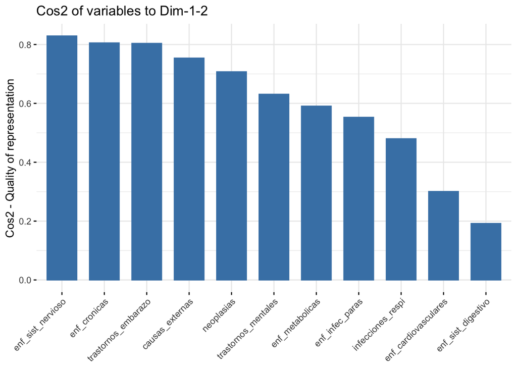

Figura 31: Calidad de representación ($\cos^2$) en el plano principal del ACP.

Finalmente, en la Figura 32 se presenta un biplot con la posición de cada país en el plano principal, coloreados según su IDH, dividido por cuartiles.

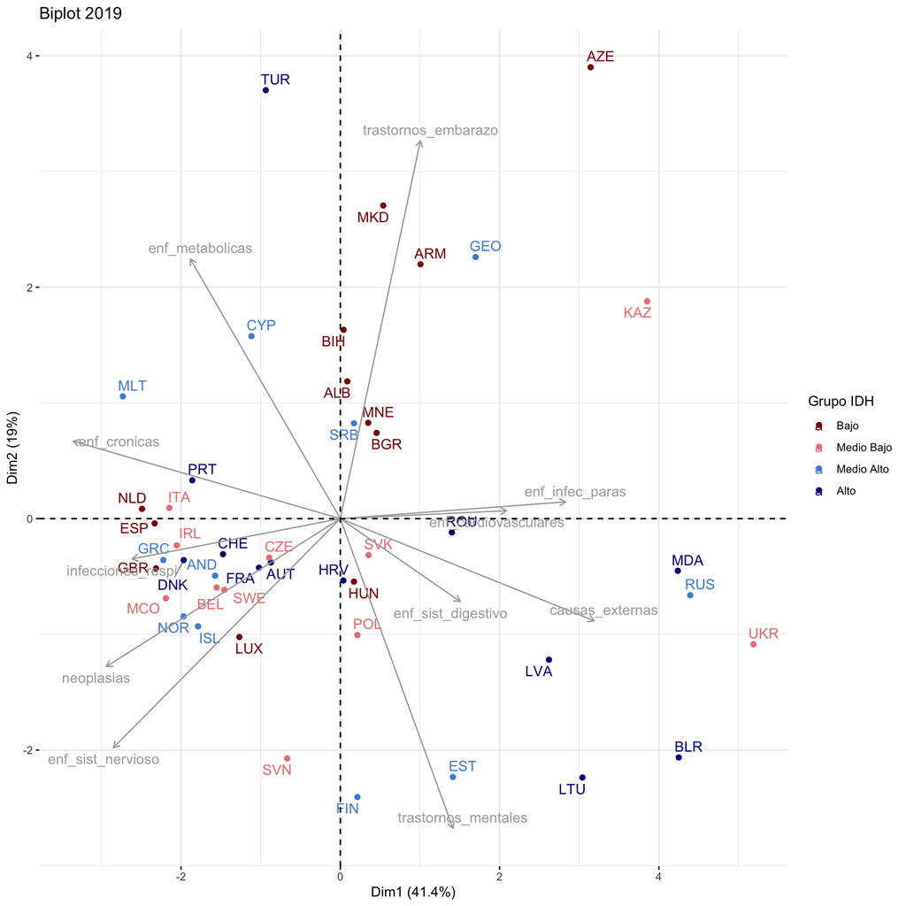

Figura 32: Representación de los países en el plano principal del ACP, coloreados según su IDH.

En este gráfico tampoco podemos ver una agrupación clara.

Para acabar veamos juntos los tres gráficos que hemos analizado:

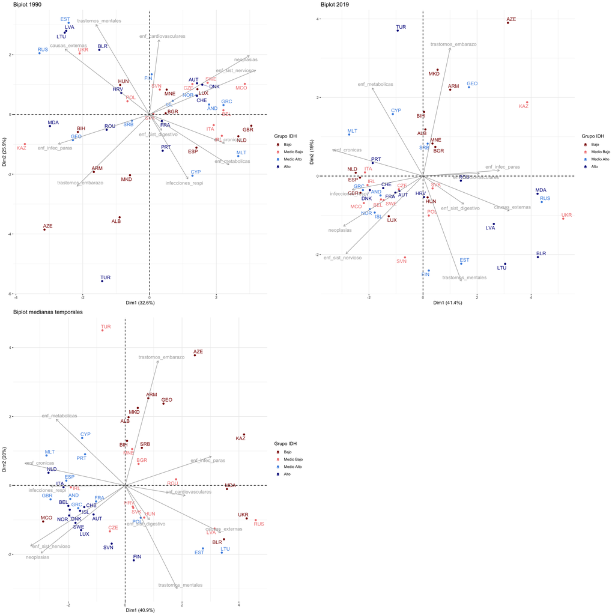

### A.2 - Análisis en coordenadas principales

Vamos a realizar también un análisis en coordenadas principales (o escalamiento multidimensional). Este análisis se hará, de nuevo, en los tres conjuntos de datos que hemos construido en el ACP. Por su naturaleza composicional, no podemos utilizar las distancias Euclídea o de Manhattan. En su lugar, utilizaremos la distancia de Aitchison, que es la distancia Euclídea entre dos muestras después de aplicar la transformación CLR. Cuando representemos los puntos, de nuevo los colorearemos según su nivel de IDH.

#### MDS medianas

Mostremos las distancias entre los primeros 8 países de la tabla.

```
         ALB      AND      ARM      AUT      AZE      BEL      BGR      BIH
ALB 0.000000 2.978497 1.982236 3.180092 2.390870 2.990935 2.476332 2.782215
AND 2.978497 0.000000 2.633241 2.069521 3.662672 1.455512 1.760401 2.101800
ARM 1.982236 2.633241 0.000000 2.598479 1.969760 2.717939 1.734217 1.366572
AUT 3.180092 2.069521 2.598479 0.000000 4.124652 1.371879 1.802093 1.780303
AZE 2.390870 3.662672 1.969760 4.124652 0.000000 3.829198 3.060792 3.043723
BEL 2.990935 1.455512 2.717939 1.371879 3.829198 0.000000 1.782482 2.268320
BGR 2.476332 1.760401 1.734217 1.802093 3.060792 1.782482 0.000000 1.402533
BIH 2.782215 2.101800 1.366572 1.780303 3.043723 2.268320 1.402533 0.000000
```

Ahora, aplicamos el método de coordenadas principales con la función de R `cmdscale`, usando la matriz de distancias anterior y especificando $k = 2$ (dos componentes principales).

```
# A tibble: 10 × 3
    Dim.1  Dim.2 grupo_idh
 *  <dbl>  <dbl> <fct>
 1 -1.02   1.42  Bajo
 2 -0.522 -0.391 Medio Alto
 3 -0.955  1.44  Bajo
 4 -0.107 -0.917 Alto
 5 -0.553  2.63  Bajo
 6 -0.365 -1.01  Alto
 7 -0.614  0.256 Medio Bajo
 8 -0.519  0.546 Bajo
 9  2.31   0.356 Bajo
10 -0.143 -0.883 Alto
```

Mostramos el gráfico de la matriz de distancias.

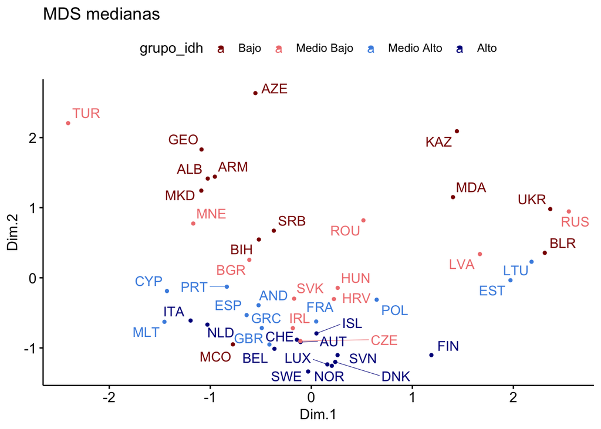

Podemos apreciar que el idh es inversamente proporcional a la segunda dimensión, ya que, de forma general, cuanto más IDH tiene un país, más abajo está.

Por último, calculemos los coeficientes de precisión a partir de los valores propios de la matriz de productos cruzados.

```
[1] 93.93596
```

```
[1] 99.85272
```

- $m_{1,2} =$ 93.9359641
- $m_{2,2} =$ 99.8527199

con lo que vemos que hay una buena representación.

#### MDS 1990

Mostremos las distancias entre los primeros 8 países de la tabla.

```
         ALB       AND      ARM       AUT      AZE      BLR       BEL      BIH
ALB 0.000000 3.6547361 2.126719 3.7138779 1.565650 4.171213 3.3419482 3.392422
AND 3.654736 0.0000000 2.839443 1.1472965 3.708782 2.334574 0.7801658 2.484708
ARM 2.126719 2.8394426 0.000000 2.7080688 1.792098 2.914615 2.6690054 1.844472
AUT 3.713878 1.1472965 2.708069 0.0000000 3.649384 2.353752 0.9917369 2.263499
AZE 1.565650 3.7087825 1.792098 3.6493836 0.000000 3.870810 3.5024897 2.780160
BLR 4.171213 2.3345743 2.914615 2.3537520 3.870810 0.000000 2.5409511 1.789643
BEL 3.341948 0.7801658 2.669005 0.9917369 3.502490 2.540951 0.0000000 2.610842
BIH 3.392422 2.4847077 1.844472 2.2634994 2.780160 1.789643 2.6108417 0.000000
```

Ahora, aplicamos el método de coordenadas principales con la función de R `cmdscale`, usando la matriz de distancias anterior y especificando $k = 2$ (dos componentes principales).

```
# A tibble: 10 × 3
      Dim.1  Dim.2 grupo_idh
 *    <dbl>  <dbl> <fct>
 1  2.44     0.827 Bajo
 2 -0.387   -0.911 Bajo
 3  1.17     1.11  Bajo
 4 -0.360   -0.840 Alto
 5  1.81     1.50  Bajo
 6 -1.48     0.817 Medio Bajo
 7  0.00611 -1.12  Alto
 8 -0.237    1.27  Bajo
 9  0.199   -0.529 Bajo
10 -0.635    0.185 Bajo
```

Mostramos el gráfico de la matriz de distancias.

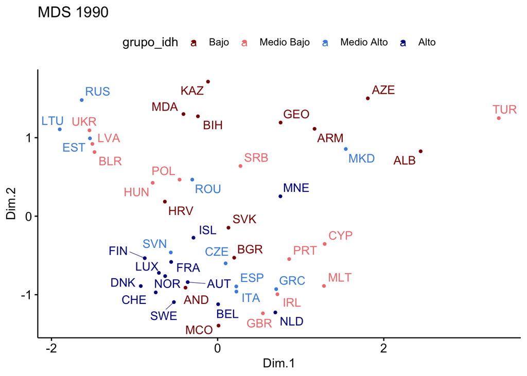

Podemos ver en la parte superior una agrupación de los países con un IDH bajo, mientras que en la parte inferior izquierda se agrupan los países con un IDH alto.

Por último, calculemos los coeficientes de precisión a partir de los valores propios de la matriz de productos cruzados.

```
[1] 93.70888
```

```
[1] 99.85779
```

- $m_{1,2} =$ 93.7088819
- $m_{2,2} =$ 99.8577879

Con estos valores de los coeficientes de precisión vemos que hay una buena representación.

#### MDS 2019

Mostremos las distancias entre los primeros 8 países de la tabla.

```
         ALB      AND      ARM      AUT      AZE      BLR      BEL      BIH
ALB 0.000000 2.790756 2.035378 2.559235 2.807594 3.731074 2.501540 2.744661
AND 2.790756 0.000000 2.412840 2.343360 3.763101 3.897638 1.895148 2.318280
ARM 2.035378 2.412840 0.000000 2.177954 2.059518 3.832924 2.383600 1.343067
AUT 2.559235 2.343360 2.177954 0.000000 3.907126 3.193728 1.398166 1.882968
AZE 2.807594 3.763101 2.059518 3.907126 0.000000 4.223308 3.838282 3.036226
BLR 3.731074 3.897638 3.832924 3.193728 4.223308 0.000000 3.512212 3.855180
BEL 2.501540 1.895148 2.383600 1.398166 3.838282 3.512212 0.000000 2.489385
BIH 2.744661 2.318280 1.343067 1.882968 3.036226 3.855180 2.489385 0.000000
```

Ahora, aplicamos el método de coordenadas principales con la función de R `cmdscale`, usando la matriz de distancias anterior y especificando $k = 2$ (dos componentes principales).

```
# A tibble: 10 × 3
     Dim.1    Dim.2 grupo_idh
 *   <dbl>    <dbl> <fct>
 1 -0.582   0.937   Bajo
 2 -0.580  -0.00406 Medio Bajo
 3 -0.594   1.37    Bajo
 4 -0.197  -0.652   Alto
 5  0.147   2.83    Bajo
 6  2.81   -0.0717  Bajo
 7 -0.448  -0.843   Alto
 8 -0.588   0.834   Bajo
 9 -0.653   0.563   Bajo
10  0.0872 -0.399   Medio Bajo
```

Mostramos el gráfico de la matriz de distancias.

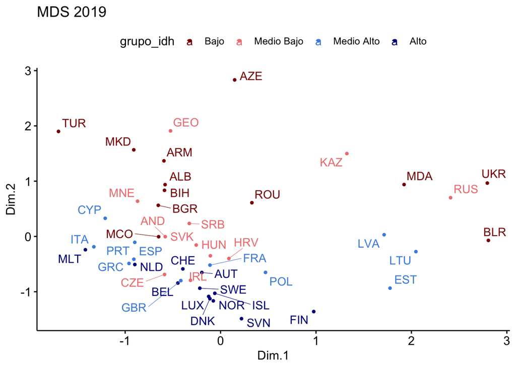

En este gráfico también se puede apreciar una transición de abajo hacia arriba de países con más IDH hacia países con menos IDH.

Por último, calculemos los coeficientes de precisión a partir de los valores propios de la matriz de productos cruzados.

```
[1] 95.06777
```

```
[1] 99.91306
```

- $m_{1,2} =$ 95.0677722
- $m_{2,2} =$ 99.9130634

Con estos valores de los coeficientes de precisión vemos que hay una buena representación.

## Bibliografía

[1]

J. J. Doblas Martínez, «GitHub repository: `TFG`». https://github.com/juanjodoblasm/TFG, 2025.

[2]

S. Lubbe, P. Filzmoser, y M. Templ, «Comparison of zero replacement strategies for compositional data with large numbers of zeros», *Chemometrics and Intelligent Laboratory Systems*, vol. 210, p. 104248, 2021, doi: https://doi.org/10.1016/j.chemolab.2021.104248.

[3]

X. Zhang y N. Yi, «NBZIMM: negative binomial and zero-inflated mixed models, with application to microbiome/metagenomics data analysis», *BMC Bioinformatics*, vol. 1, n.º 488, 2020, doi: https://doi.org/10.1186/s12859-020-03803-z.